# 기호 수학(Symbolic Math)

수학 - 통계

이광춘

[Tidyverse Korea](https://www.facebook.com/groups/tidyverse/)

2021-01-28

# 1 초등 수학

초등학교 5학년 2학기 “평균과 가능성” 단원이 등장하고 “수의 범위와 어림하기”도 최대값 최소값을 기초통계량으로 구하는데 필히 도움이 되는 내용이다.

## 1.1 이상과 이하를 알아볼까요?

준기네 반 학생들이 왕복 오래달리기를 하였습니다. 준기네 반 학생들의 기록을 알아봅시다.

| 이름 | 준기 | 명환 | 은서 | 나린 | 예은 | 상철 |
| --- | --- | --- | --- | --- | --- | --- |
| 횟수(회) | 70 | 65 | 75 | 73 | 68 | 71 |

- 왕복 오래달리기 횟수가 70회와 같거나 많은 학생의 기록을 모두 써 보세요.
  - 준기, 은서, 나린, 상철
- 70과 같거나 큰 수를 어떻게 말하면 좋을지 이야기해 보세요.
  - 70 이상인 수라고 합니다.

상기 문제를 R 코드로 작성하여 풀면 다음과 같다.

```r
run_vector <- c(70, 65, 75, 73, 68, 71)

count_over_70 <- 0

for(i in 1:length(run_vector)) {
  if(run_vector[i] >= 70) {
    count_over_70 <- count_over_70 +1
  }
}

cat("왕복 오래달리기 기록 70 이상인 학생: ", count_over_70, "\n")
```

```
왕복 오래달리기 기록 70 이상인 학생:  4
```

상기 오래달리기를 1차원 그래프로 시각화해보자.

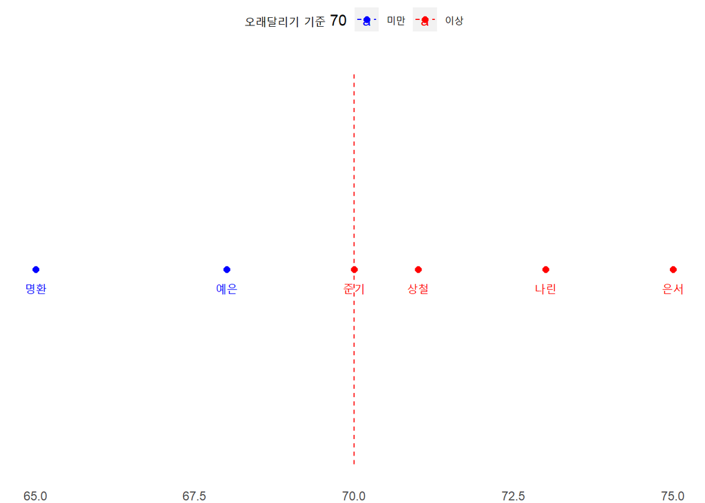

```r
library(tidyverse)

name_vector <- c("준기", "명환", "은서", "나린", "예은", "상철")

run_tbl <- tibble(기록 = run_vector,
                  이름 = name_vector) %>%
  mutate(indicator = ifelse(run_vector >=70, "이상", "미만"))

run_tbl %>%
  ggplot(aes(x=기록, y=c(0), color = indicator)) +
    geom_point(size = 2) +
    geom_text(aes(label=`이름`), vjust = 2) +
    geom_segment(x=70, xend=70, y=-0.1, yend=0.1, size=0.5, linetype = "dashed") +
    scale_y_continuous(limits = c(-0.1, 0.1)) +
    theme(axis.line=element_blank(),
          axis.text.y=element_blank(),
          axis.ticks=element_blank(),
          axis.title.x=element_blank(),
          axis.title.y=element_blank(),
          panel.background=element_blank(),
          panel.border=element_blank(),
          panel.grid.major=element_blank(),
          panel.grid.minor=element_blank(),
          plot.background=element_blank(),
          plot.margin=unit(c(0,0,0,0), "cm"),
          panel.spacing=unit(c(0,0,0,0), "cm"),
          legend.position = "top") +
  labs(color = "오래달리기 기준 70") +
  scale_color_manual(values = c("blue", "red"))
```

## 1.2 평균

준기네 반 볼링 핀 쓰러뜨리기 선수의 기록을 나타낸 표입니다. 이 선수가 쓰러뜨린 볼링핀 수의 평균을 구해 봅시다.

| 회 | 쓰러뜨린 볼링 핀의 수 |
| --- | --- |
| 1회 | 9 |
| 2회 | 6 |
| 3회 | 10 |
| 4회 | 7 |

평균을 구하는 방식은 쓰러뜨린 볼링 핀의 수를 모두 더한 후에 시행횟수만큼 나눠주면 된다.

$$\frac{9+6+10+7}{1+1+1+1} = \frac{32}{4} = 8$$

```r
trial <- c("1회", "2회", "3회", "4회")
pins  <- c(9, 6, 10, 7)

bowling_tbl <- tibble(회 = trial,
                      `핀의 수` = pins)

bowling_tbl %>%
  summarise(평균  = mean(`핀의 수`),
            평균2 = sum(`핀의 수`) / n())
```

```
# A tibble: 1 x 2
   평균 평균2
  <dbl> <dbl>
1     8     8
```

그래프로 시각화하면 다음과 같다.

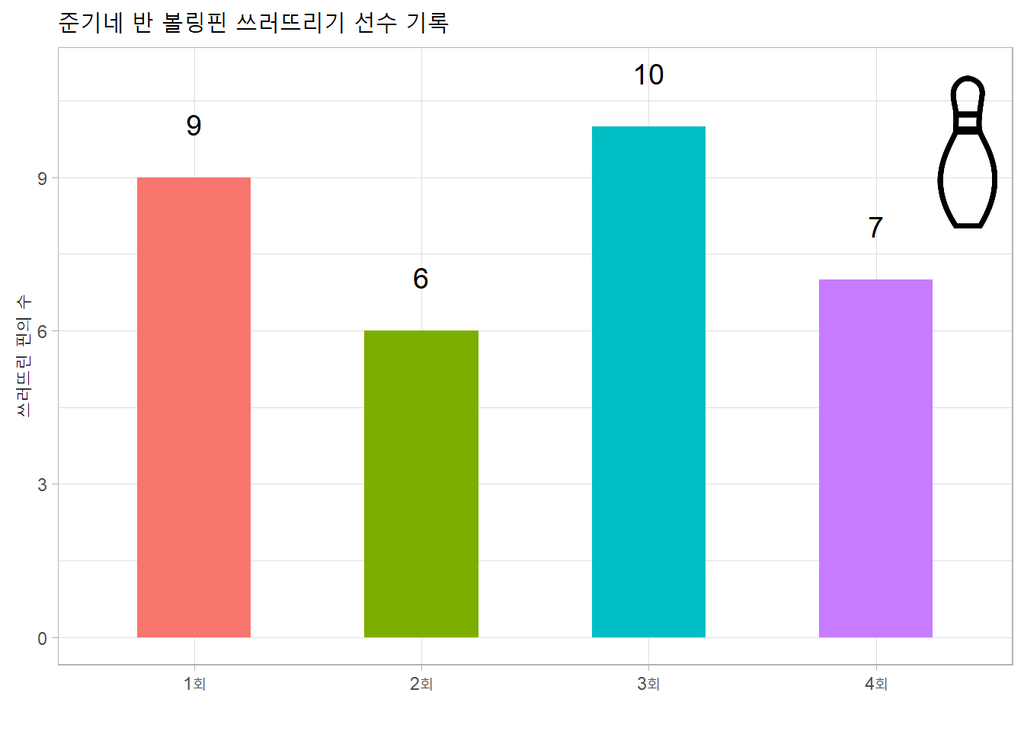

```r
library(ggimage)
library(magick)
library(cowplot)

bowling_img <- magick::image_read("fig/bowling-pins.png")

bowling_tbl %>%
  mutate(image = "fig/bowling-pins.png") %>%
  ggplot(aes(x=회, y= `핀의 수`, fill = 회)) +
    geom_col(width = 0.5) +
    geom_text(aes(label =`핀의 수`), vjust = -2, size = 5) +
    scale_y_continuous(limits = c(0,11)) +
    theme_light() +
    labs(title = "준기네 반 볼링핀 쓰러뜨리기 선수 기록",
         x = "", y="쓰러뜨린 핀의 수") +
    theme(legend.position = "none") +
    draw_image(bowling_img,  x = 3.9, y = 9, scale = 3)
```

좀더 직관적으로 표현하기 위해 점그래프(dotplot)를 사용해서 시각화를 한다.

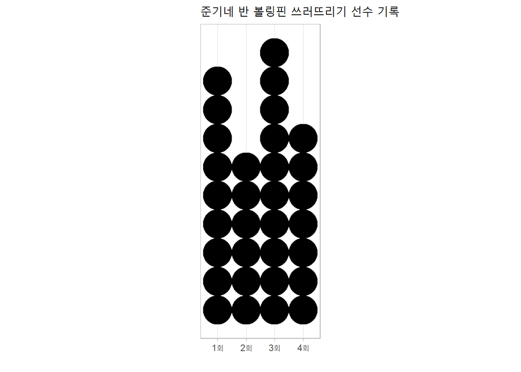

```r
bowling_tbl %>%
  tidyr::uncount(`핀의 수`) %>%
  mutate(image = "fig/bowling-pins.png") %>%
  ggplot(aes(x=회)) +
    geom_dotplot(method = 'histodot', binwidth = 1) +
    scale_y_continuous(NULL, breaks = NULL) +
    theme_light() +
    draw_image(bowling_img,  x = 3.9, y = 9, scale = 3) +
    labs(title = "준기네 반 볼링핀 쓰러뜨리기 선수 기록",
         x = "", y="쓰러뜨린 핀의 수") +
    coord_fixed(ratio = 10)
```

데이터 과학자 [이광춘](https://github.com/statkclee/) 저작

*kwangchun.lee.7@gmail.com*